# r11546014_ASS02

## 1.

### (a) 試簡述何謂維度的詛咒?試列舉一案例說明

欲分析的模型或函數其未知參數越多，需要的樣本數會成指數型成長，在做機器學習模擬其模型時，若樣本數不足，有可能會出現花很多時間學習但卻不易收斂、具多重解或過度配適的情況。  
Example  
模型：生同一種病的病人發病之原因  
每個人的身體素質不同，生病的原因有可能是心理狀況、身體狀況、壓力、工作環境、生活環境、基因等等的因素參雜，在分析生同一場病的病人們發病的原因需要考量到多方因素，故有可能會出現維度詛咒的情況，若欲減少這種情況，需要多增加樣本數。

### (b) 避免維度詛咒的方法有哪些?

1. 特徵挑選(過濾法、包裝法、嵌入法、維度縮減法)

   從原始數據中找出重要特徵集合的方法，即從原始的p個參數中挑選出重要的q個，目的為  
   i. 透過減少無關的資訊避免過度配適  
   ii. 透過減少資訊重疊性避免多元共線性  
   iii. 提升效率並節省成本
2. 維度縮減

   將原有的特徵做線性或非線性轉換，將具備相似的資訊做合併，或將差異過大的資料做分離，透過此方法可以改以較少的特徵來代表整體的資訊。

### (c) 試找一個開放數據(e.g. Kaggle 開放數據或第一次作業紅酒數據集)並選一種方法(e.g. 線性迴歸或決策樹)，用模擬方法固定樣本數但逐步增加變數個數，試著重新繪製圖 3.12， 呈現維度與預測(或分類)績效間的關係。

```python
import pandas as pd
# 將furnace.csv資料轉成DataFrame Type存至furnace_df
furnace_df = pd.read_csv("MDS_Assignment1_furnace.csv")
furnace_df.head()
```

|  | f0 | f1 | f2 | f3 | f4 | f5 | f6 | f7 | f8 | f9 | ... | f19 | f20 | f21 | f22 | f23 | f24 | f25 | f26 | f27 | grade |
| --- | --- | --- | --- | --- | --- | --- | --- | --- | --- | --- | --- | --- | --- | --- | --- | --- | --- | --- | --- | --- | --- |
| 0 | 1.848564 | -0.26425 | -0.461423 | 0.409400 | 1.305455 | 2.329398 | 0.370965 | 0.090167 | 0.107958 | 0.0 | ... | 0.085505 | 0.233285 | -1.080663 | 0.443257 | -0.406121 | -0.687687 | 0.271886 | 3.727218 | 0.102129 | 2 |
| 1 | -0.825098 | -0.26425 | 3.032397 | -2.442599 | 1.305455 | -0.276144 | 0.370965 | 0.090167 | 0.107958 | 0.0 | ... | 0.085505 | 0.233285 | -1.080663 | -0.232546 | -0.406366 | -0.687687 | 0.271886 | -0.232472 | 0.102129 | 4 |
| 2 | 1.848564 | -0.26425 | -0.461423 | 0.409400 | 1.305455 | 2.329398 | 0.370965 | 0.090167 | 0.107958 | 0.0 | ... | 0.085505 | 0.233285 | 0.925358 | 1.459782 | 1.221876 | 1.877777 | 0.271886 | -0.232472 | 0.102129 | 2 |
| 3 | 0.511733 | -0.26425 | -0.461423 | 0.409400 | -0.525726 | -0.276144 | 0.370965 | 0.090167 | 0.107958 | 0.0 | ... | 0.085505 | 0.233285 | 0.925358 | -0.008030 | -0.406366 | 1.504523 | 0.271886 | -0.232472 | 0.102129 | 2 |
| 4 | -0.825098 | -0.26425 | -0.461423 | 0.409400 | -0.525726 | -0.276144 | 0.370965 | 0.090167 | 0.107958 | 0.0 | ... | 0.085505 | 0.233285 | 0.925358 | -0.573268 | -1.164793 | 1.877777 | 0.271886 | -0.232472 | 0.102129 | 2 |

5 rows × 29 columns

```python
import statsmodels.api as sm
train_columns = furnace_df.columns[0:28]
x_train = furnace_df.loc[:, :'f27']  # 將'f0'-'f27'的值存入x_train
y_train = furnace_df['grade']  # 將'grade'的值存入y_train
x_train = sm.add_constant(x_train)  # 因需考量到數據之偏差，故加入常數變量

model = sm.OLS(y_train, x_train).fit()  # 使用最小二乘法做回歸分析
OLS_Summary = model.summary()
OLS_Summary
```

OLS Regression Results

| Dep. Variable: | grade | R-squared: | 0.495 |
| --- | --- | --- | --- |
| Model: | OLS | Adj. R-squared: | 0.472 |
| Method: | Least Squares | F-statistic: | 21.52 |
| Date: | Fri, 28 Oct 2022 | Prob (F-statistic): | 1.16e-70 |
| Time: | 17:36:07 | Log-Likelihood: | -381.52 |
| No. Observations: | 620 | AIC: | 819.0 |
| Df Residuals: | 592 | BIC: | 943.1 |
| Df Model: | 27 |  |  |
| Covariance Type: | nonrobust |  |  |

|  | coef | std err | t | P>\|t\| | [0.025 | 0.975] |
| --- | --- | --- | --- | --- | --- | --- |
| const | 2.0339 | 0.018 | 110.528 | 0.000 | 1.998 | 2.070 |
| f0 | -0.0055 | 0.025 | -0.224 | 0.823 | -0.054 | 0.043 |
| f1 | 0.0440 | 0.028 | 1.571 | 0.117 | -0.011 | 0.099 |
| f2 | 0.3140 | 0.035 | 9.028 | 0.000 | 0.246 | 0.382 |
| f3 | 0.0186 | 0.042 | 0.447 | 0.655 | -0.063 | 0.100 |
| f4 | -0.0035 | 0.038 | -0.091 | 0.928 | -0.078 | 0.072 |
| f5 | -0.0740 | 0.030 | -2.483 | 0.013 | -0.133 | -0.015 |
| f6 | -0.0710 | 0.026 | -2.742 | 0.006 | -0.122 | -0.020 |
| f7 | 0.0235 | 0.028 | 0.853 | 0.394 | -0.031 | 0.078 |
| f8 | 0.0410 | 0.019 | 2.170 | 0.030 | 0.004 | 0.078 |
| f9 | 1.293e-16 | 2.34e-17 | 5.527 | 0.000 | 8.34e-17 | 1.75e-16 |
| f10 | -0.0446 | 0.021 | -2.119 | 0.035 | -0.086 | -0.003 |
| f11 | -0.0292 | 0.020 | -1.438 | 0.151 | -0.069 | 0.011 |
| f12 | -0.0006 | 0.022 | -0.027 | 0.979 | -0.044 | 0.043 |
| f13 | 0.0336 | 0.024 | 1.412 | 0.159 | -0.013 | 0.080 |
| f14 | -0.1832 | 0.021 | -8.898 | 0.000 | -0.224 | -0.143 |
| f15 | -0.1061 | 0.019 | -5.565 | 0.000 | -0.144 | -0.069 |
| f16 | -0.0358 | 0.020 | -1.756 | 0.080 | -0.076 | 0.004 |
| f17 | 0.0633 | 0.019 | 3.409 | 0.001 | 0.027 | 0.100 |
| f18 | -0.1904 | 0.021 | -9.194 | 0.000 | -0.231 | -0.150 |
| f19 | 0.0278 | 0.026 | 1.051 | 0.294 | -0.024 | 0.080 |
| f20 | 0.0126 | 0.020 | 0.644 | 0.520 | -0.026 | 0.051 |
| f21 | -0.0357 | 0.028 | -1.263 | 0.207 | -0.091 | 0.020 |
| f22 | 0.0747 | 0.021 | 3.533 | 0.000 | 0.033 | 0.116 |
| f23 | -0.0088 | 0.020 | -0.442 | 0.659 | -0.048 | 0.030 |
| f24 | 0.0193 | 0.024 | 0.800 | 0.424 | -0.028 | 0.067 |
| f25 | -0.0679 | 0.020 | -3.406 | 0.001 | -0.107 | -0.029 |
| f26 | -0.0360 | 0.022 | -1.625 | 0.105 | -0.080 | 0.008 |
| f27 | -0.0062 | 0.019 | -0.324 | 0.746 | -0.044 | 0.031 |

| Omnibus: | 39.669 | Durbin-Watson: | 2.004 |
| --- | --- | --- | --- |
| Prob(Omnibus): | 0.000 | Jarque-Bera (JB): | 147.525 |
| Skew: | 0.090 | Prob(JB): | 9.23e-33 |
| Kurtosis: | 5.383 | Cond. No. | 2.25e+15 |

Notes:  
[1] Standard Errors assume that the covariance matrix of the errors is correctly specified.  
[2] The smallest eigenvalue is 3.98e-28. This might indicate that there are  
strong multicollinearity problems or that the design matrix is singular.

```python
ols_summary = pd.read_html(OLS_Summary.tables[1].as_html(),
                           header=0,
                           index_col=0)[0]
ols_summary = ols_summary[1:]
# 依p-value的數值小至大，將ols_summary重新排列
ols_summary.sort_values(by='P>|t|', inplace=True)
# 若p-value<0.01，則存至significant_variables
significant_variables = ols_summary[ols_summary['P>|t|'] < 0.01]
significant_variables
```

|  | coef | std err | t | P>\|t\| | [0.025 | 0.975] |
| --- | --- | --- | --- | --- | --- | --- |
| f2 | 3.140000e-01 | 3.500000e-02 | 9.028 | 0.000 | 2.460000e-01 | 3.820000e-01 |
| f18 | -1.904000e-01 | 2.100000e-02 | -9.194 | 0.000 | -2.310000e-01 | -1.500000e-01 |
| f9 | 1.293000e-16 | 2.340000e-17 | 5.527 | 0.000 | 8.340000e-17 | 1.750000e-16 |
| f22 | 7.470000e-02 | 2.100000e-02 | 3.533 | 0.000 | 3.300000e-02 | 1.160000e-01 |
| f14 | -1.832000e-01 | 2.100000e-02 | -8.898 | 0.000 | -2.240000e-01 | -1.430000e-01 |
| f15 | -1.061000e-01 | 1.900000e-02 | -5.565 | 0.000 | -1.440000e-01 | -6.900000e-02 |
| f25 | -6.790000e-02 | 2.000000e-02 | -3.406 | 0.001 | -1.070000e-01 | -2.900000e-02 |
| f17 | 6.330000e-02 | 1.900000e-02 | 3.409 | 0.001 | 2.700000e-02 | 1.000000e-01 |
| f6 | -7.100000e-02 | 2.600000e-02 | -2.742 | 0.006 | -1.220000e-01 | -2.000000e-02 |

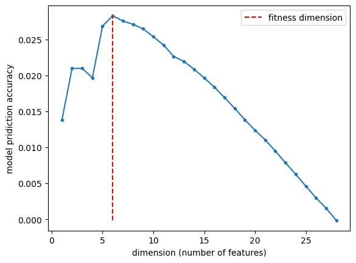

```python
import matplotlib.pyplot as plt
col_names = []  # 儲存每行名稱
x_train2 = []  # 儲存行資料
count = 0  # dimension count
counts = []
accuracy = []  # 儲存adjusted-Rsquared

for idx in significant_variables.index:
    count += 1
    counts.append(count)
    col_names.append(idx)
    x_train2 = furnace_df[col_names]
    model = sm.OLS(y_train, x_train2).fit()  # 使用最小二乘法做回歸分析
    accuracy.append(model.rsquared_adj)  # 將adjusted-Rsqare存至accuracy中

for idx in furnace_df:
    if(idx in significant_variables.index or idx == 'grade'):
        pass
    else:
        count += 1
        counts.append(count)
        col_names.append(idx)
        x_train2 = furnace_df[col_names]
        model = sm.OLS(y_train, x_train2).fit()  # 使用最小二乘法做回歸分析
        accuracy.append(model.rsquared_adj)  # 將adjusted-Rsqare存至accuracy中

plt.xlabel("dimension (number of features)")
plt.ylabel("model pridiction accuracy")
plt.plot(counts, accuracy, '.-')

max_accuracy_id = accuracy.index(max(accuracy))+1
plt.plot([max_accuracy_id, max_accuracy_id], [min(accuracy), max(
    accuracy)], '--', color='red', label="fitness dimension")
plt.legend()
```

## 2.

### (a) 試找一個開放數據(e.g. Kaggle 開放數據)，您會用什麼方法來確認資料品質的好壞?試操作一次並說明其細節。

1. 單變量

   i. 檢查統計量如平均值、中位數、眾數、變異數、偏度等等其值是否跟事實差距過大

   ```
   EX:該資料應為常態分配，但是得出來的結果為左偏，則可得出結論資料品質不佳
   ```

   ii. 透過線性回歸，檢查係數是否違背事實
2. 多變量

   i. 檢查兩變數之相關性或共變異數是否有違背事實  
   ii. 檢查信度與效度（t時間收集到的資料與t+1時間收集到的資料其分配應相同）

https://www.kaggle.com/datasets/spscientist/students-performance-in-exams

```python
exam_df = pd.read_csv("exams.csv")  # 將exams.csv資料轉成DataFrame Type存至exam_df
exam_df.head()
```

|  | gender | race/ethnicity | parental level of education | lunch | test preparation course | math score | reading score | writing score |
| --- | --- | --- | --- | --- | --- | --- | --- | --- |
| 0 | male | group A | high school | standard | completed | 67 | 67 | 63 |
| 1 | female | group D | some high school | free/reduced | none | 40 | 59 | 55 |
| 2 | male | group E | some college | free/reduced | none | 59 | 60 | 50 |
| 3 | male | group B | high school | standard | none | 77 | 78 | 68 |
| 4 | male | group E | associate's degree | standard | completed | 78 | 73 | 68 |

```python
# 學歷分類有'some high school',high school','some college','associate's degree','bachelor's degree','master's degree'
# 將上述學歷改以數字做分類，分別為0,1,2,3,4,5

exam_df['parental level of education'] = exam_df['parental level of education'].apply(
    lambda x: 0 if x == 'some high school' else x)
exam_df['parental level of education'] = exam_df['parental level of education'].apply(
    lambda x: 1 if x == 'high school' else x)
exam_df['parental level of education'] = exam_df['parental level of education'].apply(
    lambda x: 2 if x == 'some college' else x)
exam_df['parental level of education'] = exam_df['parental level of education'].apply(
    lambda x: 3 if x == 'associate\'s degree' else x)
exam_df['parental level of education'] = exam_df['parental level of education'].apply(
    lambda x: 4 if x == 'bachelor\'s degree' else x)
exam_df['parental level of education'] = exam_df['parental level of education'].apply(
    lambda x: 5 if x == 'master\'s degree' else x)
exam_df.head()
```

|  | gender | race/ethnicity | parental level of education | lunch | test preparation course | math score | reading score | writing score |
| --- | --- | --- | --- | --- | --- | --- | --- | --- |
| 0 | male | group A | 1 | standard | completed | 67 | 67 | 63 |
| 1 | female | group D | 0 | free/reduced | none | 40 | 59 | 55 |
| 2 | male | group E | 2 | free/reduced | none | 59 | 60 | 50 |
| 3 | male | group B | 1 | standard | none | 77 | 78 | 68 |
| 4 | male | group E | 3 | standard | completed | 78 | 73 | 68 |

```python
# 將'parental level of education'以及'math score'的資料存至exam_df2中
exam_df2 = pd.concat(
    [exam_df['parental level of education'], exam_df['math score']], axis=1)
exam_df2.columns = ['parental level of education', 'math score']
exam_df2.head()
```

|  | parental level of education | math score |
| --- | --- | --- |
| 0 | 1 | 67 |
| 1 | 0 | 40 |
| 2 | 2 | 59 |
| 3 | 1 | 77 |
| 4 | 3 | 78 |

```python
# 計算'parental level of education'以及'math score'資料的相關係數
exam_df2.pct_change().corr()
```

|  | parental level of education | math score |
| --- | --- | --- |
| parental level of education | 1.000000 | 0.168911 |
| math score | 0.168911 | 1.000000 |

學歷與數學成績呈現低度相關，按照常理非正常情況，故判斷此資料品質不佳

### (b) 公司或您是否有現存方法來進行資料品質的確認?如 果有(或沒有)，試依您的角度說明(或建議)確認資料品質的標準作業流程(i.e. SOP)。

1. 完整性：數數據資訊量是否完整無遺漏的被收集
2. 準確性：數據資訊量的正確性、可靠性是否可被認證
3. 存取性：可以簡便的方式檢索
4. 一致性：同樣變數在不同資料庫其資料類別是否相同、在不同時間下特徵間的相關性是否相同、相似樣本在不同時間點的機率分配是否一致
5. 異值性：樣本間具有差異，具有一定的代表性，這樣可以對決策的議題提供足夠的資訊量

### (c) 試建議三個可能衡量數據品質的量化指標(i.e. KPIs)。

技術代表性、精確度/不確定性、時間代表性  
參考：https://www.google.com/url?sa=t&rct=j&q=&esrc=s&source=web&cd=&ved=2ahUKEwiK9um8zID7AhWVpVYBHdsVA4oQFnoECBsQAQ&url=https%3A%2F%2Fwww.idbcfp.org.tw%2FgetfPdf.ashx%3Fid%3DBB65547C-EC5A-4BDF-83C4-9DA225FAC500&usg=AOvVaw1nnYj2ERBU7aI1apC5CzcF

## 3.

### 在數據科學分析架構中的決策支援階段: (a) 什麼是模型的適應性與擴充性?

一個分析架構能夠適應在不同的時間區間得到的數據變化以及在空間上的推廣，使其預測力仍能夠保持在一定的水準，則此模型居有適應性以及擴充性  
適應性：模型從無到有0->1  
擴充性：模型從某一機台/製程衍伸到起他相關機台/製程 1->N的擴充性能力

### (b) 在 AI 專案中(可根據第一題的開放數據與模型)，就您所使用的數據與建構的預測模型是否具備適用性與擴充性?為什麼?又該如何調整與改善呢?

可以從分析維度的詛咒的那張圖得知若維度超過6，則模型的預測準確率會開始下降，故隨時間改變的數據若添增了新的維度，預測力則無法維持在一定水準，若產生的新數據不具備適用性與擴充性。  
參考第一題避免維度詛咒的方法，可以分成特徵挑選以及維度縮減，透過這兩種方法，降低維度詛咒發生的可能性，讓預測模型盡可能具備適用性以及擴充性。

## 4.

### 遺漏值填補的方法包括了統計量填補、預測式填補與生成式填補 (a) 試說明這些方法分別適用於什麼樣情形

1. 統計量填補（對於數值型的數據）

   i. 對「連續型」特徵

   ```
   (1) 以最大值或最小值（最樂觀or最悲觀）進行填補
   (2) 以中位數或平均數（不增加資訊量的保守觀點）進行填補
   ```

   ii. 對「類別型」特徵

   ```
   (1) 以眾數（不增加資訊量的保守觀點）進行填補
   ```

2. 預測式填補（利用已知觀測值進行預測）

   i. K最近鄰居填補法：利用靠遺漏值最近的K觀測點的平均來填補遺漏值  
   ii. 反距離加權：利用已知的分散觀測點作為支點進行多變量內插，以支點的加權平均作為遺漏值的補值
3. 生成式填補（具有生成模型）

   i. 以生成模型生成填補數據

### (b)為什麼某特徵存在大量遺漏值不宜直接刪除?

如果缺失數據具有顯著的數據分佈規律或特徵，將之刪除可能會遺失大量特徵訊息，導致模型過度擬合或分類不準確

## 5.

### 在 UCI Machine Learning Repository 開放數據中包含了一個鋼板缺陷數據(steel plates faults dataset，https://archive.ics.uci.edu/ml/datasets/steel+plates+faults) ，一共包含了 1,941 個觀測值，而每個觀測值具有 27 個特徵以及作為目標值的 7 種缺陷。試挑選出凹 凸不平(Bumps)以及刮痕(K_Scratch)兩種缺陷進行分析。試著參考網路資源學習並撰寫程式，使用此數據回答下列問題。

### (1) 試將羅吉斯迴歸分析的結果呈現如下表，並試著解釋任一特徵與目標值之間的關係。

```python
fault_col_Names = []

fault_varFile = pd.read_excel("Faults27x7_var.xlsx", header=None)
fault_varFile = fault_varFile.astype(str)
for i in range(len(fault_varFile)):
    fault_col_Names.append(fault_varFile.iat[i, 0])

fault_df = pd.read_excel("Faults.xlsx", header=None)
fault_df.columns = fault_col_Names
fault_df.head()
```

|  | X_Minimum | X_Maximum | Y_Minimum | Y_Maximum | Pixels_Areas | X_Perimeter | Y_Perimeter | Sum_of_Luminosity | Minimum_of_Luminosity | Maximum_of_Luminosity | ... | Orientation_Index | Luminosity_Index | SigmoidOfAreas | Pastry | Z_Scratch | K_Scatch | Stains | Dirtiness | Bumps | Other_Faults |
| --- | --- | --- | --- | --- | --- | --- | --- | --- | --- | --- | --- | --- | --- | --- | --- | --- | --- | --- | --- | --- | --- |
| 0 | 42 | 50 | 270900 | 270944 | 267 | 17 | 44 | 24220 | 76 | 108 | ... | 0.8182 | -0.2913 | 0.5822 | 1 | 0 | 0 | 0 | 0 | 0 | 0 |
| 1 | 645 | 651 | 2538079 | 2538108 | 108 | 10 | 30 | 11397 | 84 | 123 | ... | 0.7931 | -0.1756 | 0.2984 | 1 | 0 | 0 | 0 | 0 | 0 | 0 |
| 2 | 829 | 835 | 1553913 | 1553931 | 71 | 8 | 19 | 7972 | 99 | 125 | ... | 0.6667 | -0.1228 | 0.2150 | 1 | 0 | 0 | 0 | 0 | 0 | 0 |
| 3 | 853 | 860 | 369370 | 369415 | 176 | 13 | 45 | 18996 | 99 | 126 | ... | 0.8444 | -0.1568 | 0.5212 | 1 | 0 | 0 | 0 | 0 | 0 | 0 |
| 4 | 1289 | 1306 | 498078 | 498335 | 2409 | 60 | 260 | 246930 | 37 | 126 | ... | 0.9338 | -0.1992 | 1.0000 | 1 | 0 | 0 | 0 | 0 | 0 | 0 |

5 rows × 34 columns

```python
x_data = fault_df.loc[:, :'SigmoidOfAreas']
y_KScatch = fault_df.K_Scatch
y_Bumps = fault_df.Bumps
#y_data = fault_df.loc[:, 'K_Scatch']
display(x_data.head())
display(y_KScatch.head())
display(y_Bumps.head())
```

|  | X_Minimum | X_Maximum | Y_Minimum | Y_Maximum | Pixels_Areas | X_Perimeter | Y_Perimeter | Sum_of_Luminosity | Minimum_of_Luminosity | Maximum_of_Luminosity | ... | Outside_X_Index | Edges_X_Index | Edges_Y_Index | Outside_Global_Index | LogOfAreas | Log_X_Index | Log_Y_Index | Orientation_Index | Luminosity_Index | SigmoidOfAreas |
| --- | --- | --- | --- | --- | --- | --- | --- | --- | --- | --- | --- | --- | --- | --- | --- | --- | --- | --- | --- | --- | --- |
| 0 | 42 | 50 | 270900 | 270944 | 267 | 17 | 44 | 24220 | 76 | 108 | ... | 0.0047 | 0.4706 | 1.0000 | 1.0 | 2.4265 | 0.9031 | 1.6435 | 0.8182 | -0.2913 | 0.5822 |
| 1 | 645 | 651 | 2538079 | 2538108 | 108 | 10 | 30 | 11397 | 84 | 123 | ... | 0.0036 | 0.6000 | 0.9667 | 1.0 | 2.0334 | 0.7782 | 1.4624 | 0.7931 | -0.1756 | 0.2984 |
| 2 | 829 | 835 | 1553913 | 1553931 | 71 | 8 | 19 | 7972 | 99 | 125 | ... | 0.0037 | 0.7500 | 0.9474 | 1.0 | 1.8513 | 0.7782 | 1.2553 | 0.6667 | -0.1228 | 0.2150 |
| 3 | 853 | 860 | 369370 | 369415 | 176 | 13 | 45 | 18996 | 99 | 126 | ... | 0.0052 | 0.5385 | 1.0000 | 1.0 | 2.2455 | 0.8451 | 1.6532 | 0.8444 | -0.1568 | 0.5212 |
| 4 | 1289 | 1306 | 498078 | 498335 | 2409 | 60 | 260 | 246930 | 37 | 126 | ... | 0.0126 | 0.2833 | 0.9885 | 1.0 | 3.3818 | 1.2305 | 2.4099 | 0.9338 | -0.1992 | 1.0000 |

5 rows × 27 columns

```
0    0
1    0
2    0
3    0
4    0
Name: K_Scatch, dtype: int64
```

```
0    0
1    0
2    0
3    0
4    0
Name: Bumps, dtype: int64
```

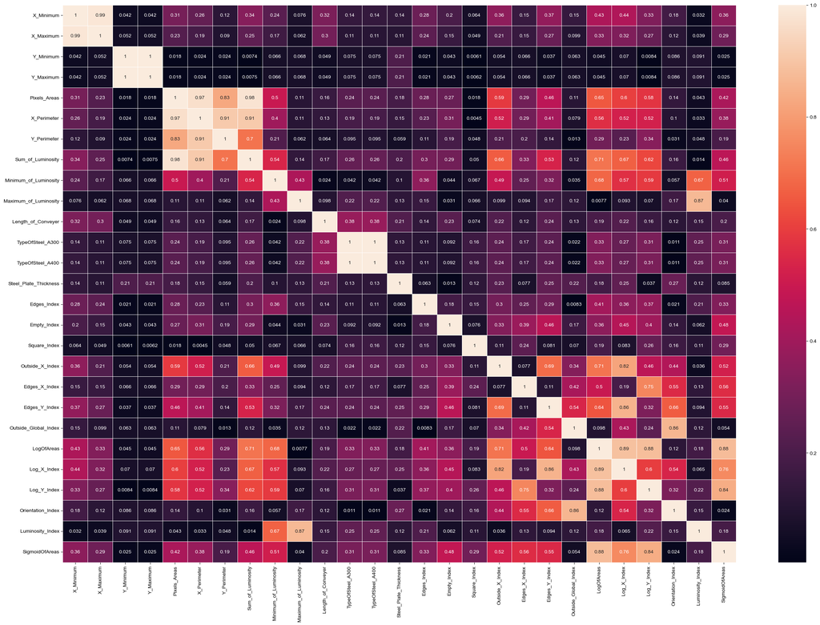

```python
# check collinearity
from collinearity import SelectNonCollinear
import seaborn as sns
import numpy as np
import matplotlib.pyplot as plt

features = x_data.columns
df = pd.DataFrame(x_data, columns=features)

fig, ax = plt.subplots(figsize=(30, 20))
sns.heatmap(df.corr().abs(), annot=True, linewidths=0.5)
sns.set(font_scale=0.8)
```

從上圖可知有需多的變數具共線性，顏色越亮表示共線性程度越高，為降低因共線性對模型可解釋變異造成影響，於此題將corr>0.8之變數捨去

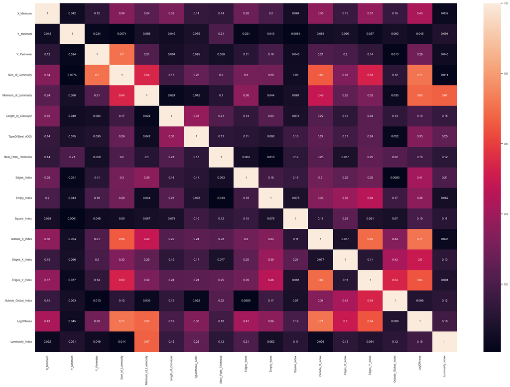

```python
# get features
selector = SelectNonCollinear(0.8)

selector.fit(np.array(x_data), np.array(y_Bumps))
mask = selector.get_support()

# 將會影響模型可解釋性的變數名稱加至constant_columns中
constant_columns = [column for column in x_data.columns
                    if column not in
                    x_data.columns[mask]]

# 將會影響模型可解釋性的變數資料從x_data中去除
x_data = x_data.drop(columns=constant_columns)
#display(x_data)
# display(x_data[:,mask])
fig, ax = plt.subplots(figsize=(30, 20))
df2=pd.DataFrame(x_data,columns=x_data.columns)
sns.heatmap(df2.corr().abs(),annot=True)
sns.set(font_scale=1.2)
```

```python
# Splitting Data
from sklearn.model_selection import train_test_split
X_train_KScatch, X_test_KScatch, Y_train_KScatch, Y_test_KScatch = train_test_split(
    x_data, y_KScatch, test_size=0.25, random_state=59)
X_train_Bumps, X_test_Bumps, Y_train_Bumps, Y_test_Bumps = train_test_split(
    x_data, y_Bumps, test_size=0.25, random_state=59)
```

```python
from sklearn import preprocessing, linear_model

# 建model
model_KScatch=sm.Logit(Y_train_KScatch,X_train_KScatch)
model_Bumps=sm.Logit(Y_train_Bumps,X_train_Bumps)

# fit model
result_KScatch=model_KScatch.fit()
result_Bumps=model_Bumps.fit()

#summary
KScatch_Summary=result_KScatch.summary()
Bumps_Summary=result_Bumps.summary()

#display
print("\ntarget: K_Scatch")
display(KScatch_Summary.tables[1])
print("target: Bumps")
display(Bumps_Summary.tables[1])
```

```
Optimization terminated successfully.
         Current function value: 0.061501
         Iterations 13
Optimization terminated successfully.
         Current function value: 0.385383
         Iterations 10

target: K_Scatch
```

|  | coef | std err | z | P>\|z\| | [0.025 | 0.975] |
| --- | --- | --- | --- | --- | --- | --- |
| X_Minimum | -0.0009 | 0.001 | -1.645 | 0.100 | -0.002 | 0.000 |
| Y_Minimum | -3.39e-07 | 1.5e-07 | -2.256 | 0.024 | -6.33e-07 | -4.44e-08 |
| Y_Perimeter | -0.0188 | 0.010 | -1.971 | 0.049 | -0.038 | -0.000 |
| Sum_of_Luminosity | 1.244e-05 | 4.75e-06 | 2.622 | 0.009 | 3.14e-06 | 2.17e-05 |
| Minimum_of_Luminosity | -0.0246 | 0.014 | -1.802 | 0.072 | -0.051 | 0.002 |
| Length_of_Conveyer | 0.0029 | 0.002 | 1.543 | 0.123 | -0.001 | 0.007 |
| TypeOfSteel_A300 | -0.7602 | 1.561 | -0.487 | 0.626 | -3.820 | 2.299 |
| Steel_Plate_Thickness | -0.1436 | 0.043 | -3.365 | 0.001 | -0.227 | -0.060 |
| Edges_Index | -2.9974 | 0.953 | -3.145 | 0.002 | -4.865 | -1.130 |
| Empty_Index | -4.6587 | 2.060 | -2.262 | 0.024 | -8.695 | -0.622 |
| Square_Index | 3.0075 | 0.970 | 3.101 | 0.002 | 1.107 | 4.908 |
| Outside_X_Index | -24.7904 | 10.845 | -2.286 | 0.022 | -46.046 | -3.535 |
| Edges_X_Index | 5.3939 | 1.353 | 3.987 | 0.000 | 2.742 | 8.046 |
| Edges_Y_Index | -5.6558 | 1.504 | -3.759 | 0.000 | -8.605 | -2.707 |
| Outside_Global_Index | 0.7391 | 0.576 | 1.282 | 0.200 | -0.391 | 1.869 |
| LogOfAreas | 2.6171 | 0.762 | 3.433 | 0.001 | 1.123 | 4.112 |
| Luminosity_Index | 12.2500 | 2.611 | 4.692 | 0.000 | 7.133 | 17.368 |

```
target: Bumps
```

|  | coef | std err | z | P>\|z\| | [0.025 | 0.975] |
| --- | --- | --- | --- | --- | --- | --- |
| X_Minimum | 0.0006 | 0.000 | 3.640 | 0.000 | 0.000 | 0.001 |
| Y_Minimum | 1.294e-07 | 3.67e-08 | 3.529 | 0.000 | 5.76e-08 | 2.01e-07 |
| Y_Perimeter | -0.0034 | 0.006 | -0.607 | 0.544 | -0.014 | 0.008 |
| Sum_of_Luminosity | -7.012e-06 | 2.91e-06 | -2.408 | 0.016 | -1.27e-05 | -1.3e-06 |
| Minimum_of_Luminosity | -0.0268 | 0.006 | -4.563 | 0.000 | -0.038 | -0.015 |
| Length_of_Conveyer | 4.396e-05 | 0.001 | 0.084 | 0.933 | -0.001 | 0.001 |
| TypeOfSteel_A300 | 1.1288 | 0.185 | 6.094 | 0.000 | 0.766 | 1.492 |
| Steel_Plate_Thickness | -0.0048 | 0.002 | -2.554 | 0.011 | -0.008 | -0.001 |
| Edges_Index | 0.9192 | 0.266 | 3.461 | 0.001 | 0.399 | 1.440 |
| Empty_Index | -1.0497 | 0.726 | -1.446 | 0.148 | -2.473 | 0.373 |
| Square_Index | 2.3119 | 0.355 | 6.510 | 0.000 | 1.616 | 3.008 |
| Outside_X_Index | -1.8191 | 10.912 | -0.167 | 0.868 | -23.206 | 19.568 |
| Edges_X_Index | -0.8387 | 0.523 | -1.602 | 0.109 | -1.865 | 0.187 |
| Edges_Y_Index | -0.9672 | 0.644 | -1.502 | 0.133 | -2.229 | 0.295 |
| Outside_Global_Index | 0.1986 | 0.215 | 0.924 | 0.356 | -0.223 | 0.620 |
| LogOfAreas | 0.4923 | 0.295 | 1.672 | 0.095 | -0.085 | 1.070 |
| Luminosity_Index | 3.4464 | 1.044 | 3.302 | 0.001 | 1.401 | 5.492 |

1. Target: K_Scatch  
   從上面表格可以看出'Y_Minimum'之p-value=0.024<0.05，具顯著證據顯示可拒絕虛無假設，此參數對於此模型具顯著性
2. Target: Bumps  
   從上面表格可以看出'Y_Minimum'之p-value=0.000<0.05，有顯著證據顯示可拒絕虛無假設，此參數對於此模型有顯著性

### (2) 基於上述(a)的結果，將上述特徵以 t value 進行排序後，哪些特徵的迴歸係數在統計上是顯著的呢(p-value<0.01)?

```python
KScatch_Summary_table1 = pd.read_html(KScatch_Summary.tables[1].as_html(),
                                      header=0,
                                      index_col=0)[0]
Bumps_Summary_table1 = pd.read_html(Bumps_Summary.tables[1].as_html(),
                                    header=0,
                                    index_col=0)[0]
# sort by z-value
KScatch_Summary_Sorted = KScatch_Summary_table1.sort_values(by='z')
KScatch_significant_variables = KScatch_Summary_Sorted[KScatch_Summary_Sorted['P>|z|'] < 0.01]

Bumps_Summary_Sorted = Bumps_Summary_table1.sort_values(by='z')
Bumps_significant_variables = Bumps_Summary_Sorted[Bumps_Summary_Sorted['P>|z|'] < 0.01]

# print Traget:K_Scatch significant variables
indexlst = []
for index in KScatch_significant_variables.index:
    indexlst.append(index)
print("Traget:K_Scatch 具顯著性的特徵參數 : \n\n" + str(indexlst))

# display Traget:K_Scatch significant variables summary table
display(KScatch_significant_variables)

# print Traget:Bumps significant variables
indexlst = []
for index in Bumps_significant_variables.index:
    indexlst.append(index)
print("Traget:Bumps 具顯著性的特徵參數 : \n\n" + str(indexlst))

# display Traget:Bumps significant variables summary table
display(Bumps_significant_variables)
```

```
Traget:K_Scatch 具顯著性的特徵參數 :

['Edges_Y_Index', 'Steel_Plate_Thickness', 'Edges_Index', 'Sum_of_Luminosity', 'Square_Index', 'LogOfAreas', 'Edges_X_Index', 'Luminosity_Index']
```

|  | coef | std err | z | P>\|z\| | [0.025 | 0.975] |
| --- | --- | --- | --- | --- | --- | --- |
| Edges_Y_Index | -5.655800 | 1.504000 | -3.759 | 0.000 | -8.605000 | -2.707000 |
| Steel_Plate_Thickness | -0.143600 | 0.043000 | -3.365 | 0.001 | -0.227000 | -0.060000 |
| Edges_Index | -2.997400 | 0.953000 | -3.145 | 0.002 | -4.865000 | -1.130000 |
| Sum_of_Luminosity | 0.000012 | 0.000005 | 2.622 | 0.009 | 0.000003 | 0.000022 |
| Square_Index | 3.007500 | 0.970000 | 3.101 | 0.002 | 1.107000 | 4.908000 |
| LogOfAreas | 2.617100 | 0.762000 | 3.433 | 0.001 | 1.123000 | 4.112000 |
| Edges_X_Index | 5.393900 | 1.353000 | 3.987 | 0.000 | 2.742000 | 8.046000 |
| Luminosity_Index | 12.250000 | 2.611000 | 4.692 | 0.000 | 7.133000 | 17.368000 |

```
Traget:Bumps 具顯著性的特徵參數 :

['Minimum_of_Luminosity', 'Luminosity_Index', 'Edges_Index', 'Y_Minimum', 'X_Minimum', 'TypeOfSteel_A300', 'Square_Index']
```

|  | coef | std err | z | P>\|z\| | [0.025 | 0.975] |
| --- | --- | --- | --- | --- | --- | --- |
| Minimum_of_Luminosity | -2.680000e-02 | 6.000000e-03 | -4.563 | 0.000 | -3.800000e-02 | -1.500000e-02 |
| Luminosity_Index | 3.446400e+00 | 1.044000e+00 | 3.302 | 0.001 | 1.401000e+00 | 5.492000e+00 |
| Edges_Index | 9.192000e-01 | 2.660000e-01 | 3.461 | 0.001 | 3.990000e-01 | 1.440000e+00 |
| Y_Minimum | 1.294000e-07 | 3.670000e-08 | 3.529 | 0.000 | 5.760000e-08 | 2.010000e-07 |
| X_Minimum | 6.000000e-04 | 0.000000e+00 | 3.640 | 0.000 | 0.000000e+00 | 1.000000e-03 |
| TypeOfSteel_A300 | 1.128800e+00 | 1.850000e-01 | 6.094 | 0.000 | 7.660000e-01 | 1.492000e+00 |
| Square_Index | 2.311900e+00 | 3.550000e-01 | 6.510 | 0.000 | 1.616000e+00 | 3.008000e+00 |

### (3) 試問配適一個羅吉斯迴歸模型是否合適?試若配適不佳，試說明其可能的原因為何?

```python
from sklearn.linear_model import LogisticRegression

logreg_KScatch = LogisticRegression(random_state=59)
logreg_Bumps = LogisticRegression(random_state=59)

# fit the model with data
modelLR_KScatch = logreg_KScatch.fit(X_train_KScatch, Y_train_KScatch)
modelLR_Bumps = logreg_Bumps.fit(X_train_Bumps, Y_train_Bumps)

# model R2
print("Bumps訓練集R^2 : ",
      modelLR_Bumps.score(X_train_Bumps, Y_train_Bumps))
print("Bumps測試集R^2 : ",
      modelLR_Bumps.score(X_test_Bumps, Y_test_Bumps))

print("K_Scatch訓練集R^2 : ",
      modelLR_KScatch.score(X_train_KScatch, Y_train_KScatch))
print("K_Scatch測試集R^2 : ",
      modelLR_KScatch.score(X_test_KScatch, Y_test_KScatch))
```

```
Bumps訓練集R^2 :  0.7890034364261168
Bumps測試集R^2 :  0.7839506172839507
K_Scatch訓練集R^2 :  0.9367697594501718
K_Scatch測試集R^2 :  0.9465020576131687
```

1. 由上可知目標值為Bumps的模型其R2雖然數值不高，但擬合程度仍算不錯，故羅吉斯回歸模型適合用於分析次次作業案例。
2. 由上可知目標值為K_Scratch的模型其R2很接近1，擬合程度很好，故羅吉斯回歸模型適合用於分析次次作業案例。

### (4) 試問配適一個線性判別分析模型是否合適?若配適不佳，試說明其可能的原因為何?

```python
from sklearn.discriminant_analysis import LinearDiscriminantAnalysis
from sklearn.model_selection import RepeatedStratifiedKFold
from sklearn.model_selection import cross_val_score
import numpy as np

# fit LDA model
LDAreg_KScatch = LinearDiscriminantAnalysis()
modelLDA_KScatch = LDAreg_KScatch.fit(X_train_KScatch, Y_train_KScatch)

LDAreg_Bumps = LinearDiscriminantAnalysis()
modelLDA_Bumps = LDAreg_Bumps.fit(X_train_Bumps, Y_train_Bumps)

# define method to evaluate model
cv = RepeatedStratifiedKFold(n_splits=15, n_repeats=5, random_state=59)

# evaluate model
KScatch_score = cross_val_score(
    modelLDA_KScatch, X_train_KScatch, Y_train_KScatch, scoring='accuracy', cv=cv, n_jobs=-1)
print("目標值為K_Scatch的模型R2：",np.mean(KScatch_score))

Bumps_score = cross_val_score(
    modelLDA_Bumps, X_train_Bumps, Y_train_Bumps, scoring='accuracy', cv=cv, n_jobs=-1)
print("目標值為Bumps的模型R2：",np.mean(Bumps_score))
```

```
目標值為K_Scatch的模型R2： 0.9554639175257733
目標值為Bumps的模型R2： 0.8219931271477661
```

1. 由上可知目標值為K_Scratch的模型其R2很接近1，擬合程度很好，故線性判別分析適合用於分析次次作業案例。
2. 由上可知目標值為Bumps的模型其R2雖然數值沒有K_Scatch模型的R2高，但擬合程度仍算不錯，故線性判別分析模型適合用於分析次次作業案例。

### (5) 試問配適一個二次判別分析模型是否合適?若配適不佳，試說明其可能的原因為何?

```python
from sklearn.discriminant_analysis import QuadraticDiscriminantAnalysis

# fit QDA model
QDAreg_KScatch=QuadraticDiscriminantAnalysis()
modelQDA_KScatch=QDAreg_KScatch.fit(X_train_KScatch,Y_train_KScatch)

QDA_Bumps=QuadraticDiscriminantAnalysis()
modelQDA_Bumps=QDA_Bumps.fit(X_train_Bumps,Y_train_Bumps)

# evaluate model
print("目標值為K_Scatch的模型之R2 : ",modelQDA_KScatch.score(X_test_KScatch,Y_test_KScatch))
print("目標值為Bumps的模型之R2 : ",modelQDA_Bumps.score(X_test_Bumps,Y_test_Bumps))
```

```
目標值為K_Scatch的模型之R2 :  0.9650205761316872
目標值為Bumps的模型之R2 :  0.6522633744855967
```

1. 由上可知目標值為K_Scratch的模型其R2很接近1，擬合程度很好，然而目標值為Bumps的模型其R2僅0.652，擬合程度不佳，故線性二次判別分析模型並不適合用於分析次次作業案例。